# Introduction to Logistic Regression, Species Distribution and Habitat Selection - Part 2

Jared Stabach, Smithsonian Conservation Biology Institute

11 April 2021

# Introduction

In this exercise (part 2 of 2), we will walk through the steps of fitting a logistic regression model to model the probability of addax occurrence. The entire occurrence dataset is provided, with all associated variables already extracted (so that we could focus on the modeling). Animal counts (addax, but also dorcas gazelle) were summarized at plot locations. We re-coded all counts within a 2.5-km radius to a measure of occurrence (i.e., presence/absence). Thus, we modeled the data as a series of 1’s and 0’s, representing addax occurrence at plot locations. Data were aggregated in this fashion because of variability between surveys (i.e., the transects locations didn’t overlap exactly) and because we did not have confidence in the accuracy of the number of individuals recorded at each sighting. In addition, distance to animal sighting locations were only recorded in a subset of the surveys. Sightings >500-m from the transect were removed due to an assumed undercounting bias (confirmed by investigating the frequency of sightings in relation to distance). This allowed for a conservative broad-scale approach to incorporate extremely messy field data collected over multiple years. See more details in Stabach et al. 2017.

# Lab Excercise

In today’s lecture, we will:

- Summarize the occurrence dataset
- Scale/center parameter Values
- Assess potential collinearity between variables
- Apply logistic regression to model the probability of occurrence of Addax
- Graph response curves and interpret coefficients
- Validate the result
- Make a predictive surface

## Summarize the Occurrence Dataset

As a first step, we will summarize the occurrence dataset and visualize some of the patterns.

### Load Packages

As previously, we remove objects in [R’s](https://cran.r-project.org/) memory and load the necessary packages to perform the analyses. Please use the `help()` for any operations that you don’t understand or that require additional information. Knowing what to search for in [Google](https://www.google.com/) is essential. I usually start any query with “r-cran” (e.g., “r-cran Import shapefile”) to limit the search terms to [R](https://cran.r-project.org/).

```r
# Remove objects from memory
rm(list=ls())

# Load required libraries
library(arm)
library(DAAG)
library(dplyr)
library(leaflet)
library(lubridate)
library(pROC)
library(tmap)
library(usdm)
library(visreg)
library(sjPlot)
```

### Load Data

Load the data from the previous session. The included `.Rdata` file includes the occurrence dataset (`Occ`) and the two raster layers (`ndvi` and `rough`) that we will need to make a predictive surface.

Columns in the dataframe include *Date* of survey, *X* and *Y* location of each plot, the number of addax and dorcas gazelle sighted at each location, a unique plot ID (*Pt_ID*), and the presence/absence of vegetation species *Cornulaca monocantha* (Cornul), *Stipagrostis acutiflora* (Stipa1), and *Stipagrostis vulnerans* (Stipa2). These vegetation species were thought *a priori* to influence addax occurence and were collected at each plot location. *Human* disturbance (e.g., footprint, sighting, tire tracks) were also recorded (i.e., *Human* = 1). You’ll also note that the remote sensing data that we extracted, surface roughness (*Rough*) and the Normalized Difference Vegetation Index (*NDVI*), are also included.

```r
# Load the Data Frame and see that ndvi, rough, and Occ are added to your R environment
# The NDVI image is from November 2017 and will be used in our prediction
# Note: I converted the spatialpointsdataframe to a simple dataframe for the analyses
load(file="Data/Addax_Dataset.RData")

# Look at data
head(Occ)
```

```
##   Pt_ID       Date YearMonth        X       Y Addax Dorcas Cornul Stipa1 Stipa2
## 1     1 2008-12-06    200812 767911.0 1742830     0      0      0      0      0
## 2     2 2008-12-06    200812 770769.0 1744528     0      0      0      0      0
## 3     3 2008-12-06    200812 776095.8 1747469     0      5      0      1      0
## 4     4 2008-12-06    200812 780842.3 1750128     0      4      0      1      0
## 5     5 2008-12-06    200812 785517.3 1752312     0     16      0      0      0
## 6     6 2008-12-06    200812 790001.9 1754484     0      6      0      1      0
##   Human    rough      ndvi
## 1     0 8.343433 0.1223870
## 2     0 7.700197 0.1219408
## 3     0 5.044250 0.1201930
## 4     0 5.331611 0.1287899
## 5     0 6.293324 0.1247775
## 6     0 6.445662 0.1234554
```

```r
# Or get fancy with how the data table is displayed.  R has many, many different options.
#library(DT)
#datatable(Occ, rownames = FALSE, filter="top", options = list(pageLength = 5, scrollX = T))
```

### Data Cleaning

We need to add a few things to the dataframe, which most importantly includes re-coding the abundance records to a measure of occurrence. This was done because of a lack of confidence in the exact counts collected. Here, we create a `Month`, `Year`, and `Season` field, correct some of the field types, and re-code the occurrence.

```r
# Create month, year and season fields
Occ <- Occ %>% mutate(
  Month = month(Date),
  Year = year(Date),
  Season = case_when(
    Month >=3 & Month <= 6 ~ "Dry",
    Month >=7 & Month <=10 ~ "Wet",
    Month >=11 & Month <=12 ~ "Cold",
    TRUE ~ "Fix Problem"
  )
)

# Case_when is the same as:
#Occ$Season <- ifelse(Occ$Month >=3 & Occ$Month <=6, "Dry",
#                          ifelse(Occ$Month >=7 & Occ$Month <=10, "Wet",
#                                 ifelse(Occ$Month >=11 & Occ$Month <=12, "Cold","Fix Problem")
#                          ))

# We could easily include the following in the piping above.
# Recode Occurrence
Occ$obsAddax <- ifelse(Occ$Addax > 0, 1, 0)
Occ$obsDorcas <- ifelse(Occ$Dorcas > 0, 1, 0)

# Add some summaries
Occ$Both <- Occ$obsAddax + Occ$obsDorcas
Occ$Both2 <- ifelse(Occ$Both > 1, 1, 0) # Both species present/occurred
Occ$One <- ifelse(Occ$Both > 0, 1, 0) # At least one species present/occurred

# Correct the data types
cols <- c("Cornul", "Stipa1", "Stipa2", "Season", "Year")
Occ[cols] <- lapply(Occ[cols], factor) # You could change these individually, but this is more succinct Occ$Cornul <- factor(Occ$Cornul)
#str(Occ)
```

### Data Summary

When we summarize the dataset, we see that the data were collected multiple times a year and that the occurrence of addax (and dorcas gazelle) vary between years and seasons.

```r
# Summarize
Occ.Summary <- Occ %>%
  group_by(Year, Month, Season) %>%
  summarize(PresAddax = sum(obsAddax),
            PresDorc = sum(obsDorcas),
            PrevAdd= round(sum(obsAddax)/length(obsAddax)*100,digits=1),
            PrevDorc = round(sum(obsDorcas)/length(obsAddax)*100,digits=1),
            One = round(sum(One)/length(obsAddax)*100,digits=1) ,
            Both = round(sum(Both2)/length(obsAddax)*100,digits=1)
            )

# Look at the result
Occ.Summary <- as.data.frame(Occ.Summary)
Occ.Summary
```

```
##    Year Month Season PresAddax PresDorc PrevAdd PrevDorc  One Both
## 1  2008    12   Cold        22       28    33.3     42.4 68.2  7.6
## 2  2009     6    Dry         6       16     9.1     24.2 28.8  4.5
## 3  2009     9    Wet         8       19    12.1     28.8 39.4  1.5
## 4  2009    12   Cold        16       33    24.2     50.0 63.6 10.6
## 5  2010     4    Dry         4       15     6.1     22.7 24.2  4.5
## 6  2010     6    Dry         8       19    12.1     28.8 37.9  3.0
## 7  2010    10    Wet         3       13     4.5     19.7 24.2  0.0
## 8  2010    12   Cold        14       29    15.9     33.0 44.3  4.5
## 9  2011     3    Dry         7        4    15.9      9.1 15.9  9.1
## 10 2011     7    Wet        10       12    15.2     18.2 24.2  9.1
## 11 2012    12   Cold         8        9    12.1     13.6 21.2  4.5
## 12 2013    11   Cold        16       35    24.2     53.0 60.6 16.7
## 13 2014     3    Dry         4        9     6.1     13.6 16.7  3.0
## 14 2014     9    Wet         4        8     6.1     12.1 18.2  0.0
## 15 2014    12   Cold         1       34     1.5     51.5 51.5  1.5
```

```r
# If you want, write to a file
#write.csv(Occ.Summary, file="Addax_Dorcas_Prevalence.csv", quote = FALSE, row.names = FALSE)
```

### Plot Data

Let’s look at the data one last time before moving on to the modelling.

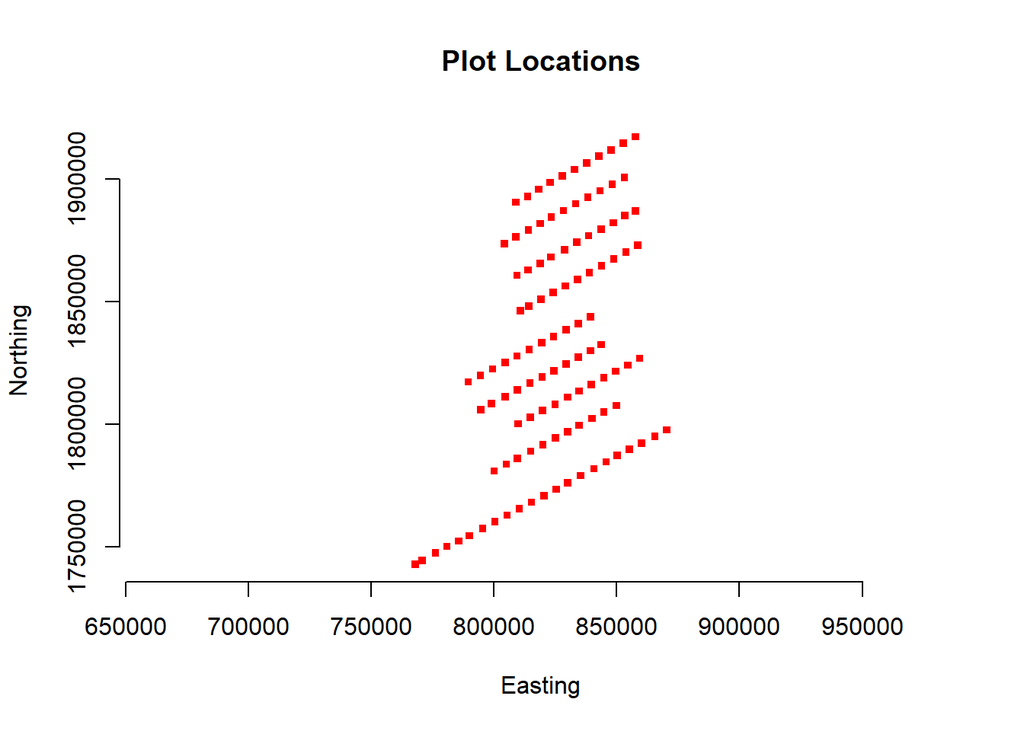

```r
# Plot
plot(Occ$X,Occ$Y,xlab = "Easting", ylab = "Northing", main = "Plot Locations", frame = FALSE, pch = ".", col="red", cex = 5, asp=1)
```

**Question:**

1. The field team didn’t visit the same plots every year or month. Based on Qiongyu’s instructions last week, how would we `loop` over the dataset to plot individual years and show which plots they visited?